[O’Hara on GitHub](https://github.com/oharac)

# Map FV-weighted IUCN extinction risk

Compiled on Tue May 17 09:18:44 2022 by ohara

```r
knitr::opts_chunk$set(echo = TRUE, message = FALSE, warning = FALSE, fig.height = 3, fig.width = 12)

library(terra)
library(oharac)
library(data.table)
library(tidyverse)
library(here)
source(here('common_fxns.R'))
```

# 1 Summary

Apply extinction risk categories (by linear score, 0 = LC, 1 = EX) to IUCN-assessed spp in this analysis. Calculate FV-weighted extinction risk across all FEs (gapfilling NAs to the mean value for the cell). Also calculate unweighted for comparison, as well as standard deviations.

# 2 Data

- AquaMaps and IUCN rangemaps
- IUCN RedList conservation status/extinction risk
- FishBase/SeaLifeBase and vulnerability framework data for functional entity assignments

# 3 Methods

Read in AquaMaps and IUCN maps and vulnerability scores. AquaMaps maps will exclude species with fewer than 10 occurrence cells, and will use a probability threshold of 0.5.

To calculate functional vulnerability of species within a cell, we must know all species in that cell (and their FE membership). But loading in all spp maps simultaneously will likely be too memory intensive. Because of the number of cells and species, we will break the map into chunks of e.g., 100,000 cells at a time. For each chunk, we will read in each species map, filtering to the chunk cells only to keep the memory needs down, bind the lookup of species-to-functional entity, calculate functional vulnerability for each FE for each cell. Then, for that chunk, bind IUCN scores and calculate FV-weighted mean and sd extinction risk. Then bind rows for all chunks.

## 3.1 Set up dataframe of species

This includes information on species vulnerability scores, functional entity ID and traits, as well as which species are mapped in which sources (including rangemap filenames).

```r
iucn_risk <- read_csv(here('_data/iucn_spp/iucn_marine_spp_info_2021-3.csv')) %>%
  select(iucn_sid, cat_score) %>%
  filter(!is.na(cat_score))
spp_info_df <- assemble_spp_info_df(fe_only = TRUE) %>%
  select(species, iucn_sid, sciname, fe_id, src, id, map_f) %>%
  distinct() %>%
  left_join(iucn_risk, by = 'iucn_sid')
```

## 3.2 Set up functions to process the various steps

To calc functional vulnerability, we need to know ALL species in each cell (and their FE membership). So we will process maps in chunks, collecting all spp but cropping down their range to just those cells in the chunk.

```r
read_truncated_rangemap <- function(f, chunk_start, chunk_end) {
  ### f <- spp_map_fs$map_f[13]

  ### Identify the source from filename (for filtering by presence or prob)
  src <- ifelse(str_detect(basename(f), 'iucn_spp_mol'), 'iucn', 'am')
  df <- data.table::fread(f) %>%
    filter(between(cell_id, chunk_start, chunk_end)) %>%
    mutate(map_f = f)
  if(src == 'iucn') {
    df <- df %>%
      filter(presence != 5) %>%
      select(-presence)
  } else {
    df <- df %>%
      filter(prob >= .5) %>%
      select(-prob)
  }
  if(nrow(df) == 0) return(NULL) else return(df)
}

bind_maps_list <- function(chunk_maps_list, spp_map_fs) {
  if(check_tryerror(chunk_maps_list)) {
    stop('Try-error found when binding truncated maps list!')
  }

  chunk_maps_raw <- chunk_maps_list %>%
    ### drop NULL instances (no spp cells - helps keep things from crashing)
    purrr::compact() %>%
    data.table::rbindlist()

  if(nrow(chunk_maps_raw) > 0) {
    ### if no spp-cell data for this chunk, skip bind and return 0-length df
    chunk_maps_raw <- chunk_maps_raw %>%
      oharac::dt_join(spp_map_fs, by = 'map_f', type = 'left') %>%
      select(-map_f) %>%
      distinct()
  }
  return(chunk_maps_raw)
}
```

Functional vulnerability for a functional entity will be calculated based on the number of species $N_{spp}$ in the FE:

$$FV_{FE} = \frac{1}{2^{N_{spp}-1}}$$

#### 3.2.0.1 Note on mean and sd:

Here, we are calculating the FV-weighted mean (and sd) extinction risk across all spp/FEs in a cell. The unit of analysis is a functional entity, and weighted not by the number of species in each FE but rather by the functional vulnerability of that FE. We will simply report the FV-weighted mean extinction risk across all FEs in the cell, and standard deviation of FV-weighted mean across all FEs.

How to address data-deficient or unassessed species? Fill with mean across all assessed spp in the cell (equally weighted)?

```r
mc_process_ext_risk_chunk <- function(spp_maps_df, spp_info_df) {

  chunk_spp_scores <- spp_info_df %>%
    filter(species %in% chunk_maps$species) %>%
    group_by(species) %>%
    summarize(cat_score = mean(cat_score, na.rm = TRUE))

  cell_id_df <- data.frame(cell_id = chunk_maps$cell_id %>% unique()) %>%
    mutate(cell_gp = rep(1:100, length.out = n()))
  cell_gps <- cell_id_df$cell_gp %>% unique()

  chunk_spp_ext_risk_maps <- chunk_maps %>%
    oharac::dt_join(chunk_spp_scores, by = 'species', type = 'inner')

  ### parallelize for speed! balance vectorization with parallel to reduce crashing...
  chunk_risk_sum_list <- parallel::mclapply(cell_gps, mc.cores = 25,
          FUN = function(gp) { ### gp <- 1
            cell_ids <- cell_id_df %>% filter(cell_gp == gp) %>% .$cell_id

            df_unwt <- chunk_spp_ext_risk_maps %>%
              filter(cell_id %in% cell_ids) %>%
              data.table() %>%
              ### impute NAs using mean across all spp in cell
              .[ , cat_score := ifelse(is.na(cat_score), mean(cat_score, na.rm = TRUE), cat_score),
                 by = .(cell_id)] %>%
              ### Summarize unweighted mean and sd across all spp; na.rm unnecessary
              .[ , .(unwt_mean_risk = mean(cat_score),
                     unwt_sdev_risk = sd(cat_score)),
                 by = .(cell_id)]

            df <- chunk_spp_ext_risk_maps %>%
              filter(cell_id %in% cell_ids) %>%
              data.table() %>%
              ### impute NAs using mean across all spp in cell
              .[ , cat_score := ifelse(is.na(cat_score), mean(cat_score, na.rm = TRUE), cat_score),
                 by = .(cell_id)] %>%
              ### summarize mean per cell and FE
              .[ , .(score_mean = mean(cat_score),
                     score_sd   = sd(cat_score),
                     ### super-tiny fv (~ 1e-20) result in Inf var
                     fv = first(fv) %>% round(10)),
                 by = .(cell_id, fe_id)] %>%
              ### summarize FV-weighted mean across all FEs
              .[ , .(n_fe = n_distinct(fe_id),
                     fv_mean = mean(fv),
                     fvwt_mean_risk = Hmisc::wtd.mean(score_mean,     weights = fv),
                     fvwt_sdev_risk = Hmisc::wtd.var(score_mean, weights = fv) %>%
                                         sqrt() %>% round(10)),
                 by = .(cell_id)] %>%
              ### bind unweighted df
              dt_join(df_unwt, by = 'cell_id', type = 'full')
          })
  if(check_tryerror(chunk_risk_sum_list)) {
    stop('Try error results in mc_process_risk_chunk...')
  }
  chunk_risk_sum_df <- data.table::rbindlist(chunk_risk_sum_list)
  return(chunk_risk_sum_df)
}
```

## 3.3 Set up loop over chunks of cells

For each chunk of cells, save out temp files of extinction risk metrics - fv-weighted mean, fv-weighted sd, number of functional entities, mean functional vulnerability across FEs - to be combined later.

```r
spp_map_fs <- spp_info_df %>%
  select(species, map_f) %>%
  distinct()
spp_fe <- spp_info_df %>%
  select(species, fe_id) %>%
  distinct()

chunk_size <- 100000
n_chunks <- ceiling(6.5e6 / chunk_size)

tmp_stem <- here('tmp/ext_risk_fe_wt_chunks/ext_risk_summary_chunk_%s_to_%s.csv')
  ### format will be: chunk start, chunk end
### zxcv <- list.files(dirname(tmp_stem), full.names = TRUE)
### unlink(zxcv)

for(chunk_i in 1:n_chunks) {
  ### chunk_i <- 2
  ### chunk_i <- 30

  ### Set up chunk start and end and filenames; check whether maps
  ### all stressors for this chunk...
  chunk_start <- (chunk_i - 1) * chunk_size + 1
  chunk_end   <- as.integer(chunk_i * chunk_size)
  chunk_text  <- sprintf('chunk %s of %s (cells %s to %s)',
                         chunk_i, n_chunks, chunk_start, chunk_end)

  ### check if all chunk-stressor maps are complete
  tmp_f <- sprintf(tmp_stem, chunk_start, chunk_end)
  if(file.exists(tmp_f)) {
    message('Extinction risk summaries exist for ', chunk_text, '... skipping!')
    next()
  }

  ### Passed the test - therefore, some chunk maps remain, so continue:
  ### Load species rangemaps for this chunk, then clean and bind:
  message('Loading ', nrow(spp_map_fs), ' rangemaps cropped for ', chunk_text,  '...')

  chunk_maps_list <- parallel::mclapply(spp_map_fs$map_f, mc.cores = 40,
                                        FUN = read_truncated_rangemap,
                                        chunk_start = chunk_start, chunk_end = chunk_end)

  chunk_maps_raw <- bind_maps_list(chunk_maps_list, spp_map_fs)

  ### OK, now we have species and cells for this chunk.  Calculate functional vulnerability!
  message('Calculating functional vulnerability metrics for ', nrow(chunk_maps_raw),
          ' spp-cells in ', chunk_text, '...')
  chunk_maps <- chunk_maps_raw %>%
    calc_spp_cell_fv(spp_fe)

  message('In ', chunk_text,  ' rangemap dataframe: \n    ', nrow(chunk_maps),
          ' cell observations for ', n_distinct(chunk_maps$species), ' species across ',
          n_distinct(chunk_maps$fe_id), ' functional entities...')


  ### For this chunk, summarize FV-weighted mean and sd
  message('Processing mean/sd extinction risk in ', chunk_text, '...')
  chunk_risk_sum <- mc_process_ext_risk_chunk(chunk_maps, spp_info_df)

  write_csv(chunk_risk_sum, tmp_f)
}
```

### 3.3.1 Aggregate temp maps to all species

```r
chunk_sum_df <- data.frame(f = list.files(dirname(tmp_stem), full.names = TRUE,
                                          pattern = 'ext_risk_summary_chunk'))

fvmean_out_file <- here('_output/risk_maps/ext_risk_fvwt_mean.tif')
fvsdev_out_file <- here('_output/risk_maps/ext_risk_fvwt_sdev.tif')
unmean_out_file <- here('_output/risk_maps/ext_risk_unwt_mean.tif')
unsdev_out_file <- here('_output/risk_maps/ext_risk_unwt_sdev.tif')

### Combine mean, sdev, and n_fe maps by taxon into one big dataframe
message('Processing mean, sd maps across all species for extinction risk...')

stats_list <- parallel::mclapply(chunk_sum_df$f, mc.cores = 33,
                                 FUN = read_csv, show_col_types = FALSE)
if(check_tryerror(stats_list)) {
  stop('Encountered try-error in reading FV-weighted vuln summary files...')
}
stats_df <- stats_list %>%
  data.table::rbindlist()

fvmean_rast <- map_to_mol(stats_df, which = 'fvwt_mean_risk')
fvsdev_rast <- map_to_mol(stats_df, which = 'fvwt_sdev_risk')
unmean_rast <- map_to_mol(stats_df, which = 'unwt_mean_risk')
unsdev_rast <- map_to_mol(stats_df, which = 'unwt_sdev_risk')

writeRaster(fvmean_rast, fvmean_out_file, overwrite = TRUE)
writeRaster(fvsdev_rast, fvsdev_out_file, overwrite = TRUE)
writeRaster(unmean_rast, unmean_out_file, overwrite = TRUE)
writeRaster(unsdev_rast, unsdev_out_file, overwrite = TRUE)

### Check that # of FEs match with other parts of analysis
# n_fe_rast_main <- rast(here('_output/nspp_maps/n_fe_in_fvwt_vuln.tif'))
# n_fe_rast_fvwt <- map_to_mol(stats_df, which = 'n_fe')
# x <- as.vector(values(n_fe_rast_fvwt)); y <- as.vector(values(n_fe_rast_main))
# match <- (is.na(x) & is.na(y)) | x == y
# all(match)
```

## 3.4 Plot maps

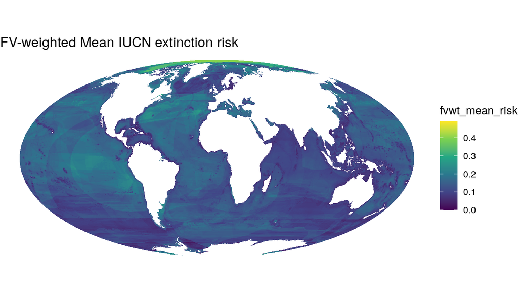

```r
diff_map <- (fvmean_rast - unmean_rast) / unmean_rast

fvmean_df <- as.data.frame(fvmean_rast, xy = TRUE)
eqmean_df <- as.data.frame(unmean_rast, xy = TRUE)
diff_df <- as.data.frame(diff_map, xy = TRUE) %>%
  setNames(c('x', 'y', 'diff'))

ggplot(fvmean_df, aes(x, y, fill = fvwt_mean_risk)) +
  geom_raster() +
  scale_fill_viridis_c() +
  theme_void() +
  coord_sf() +
  labs(title = 'FV-weighted Mean IUCN extinction risk')
```

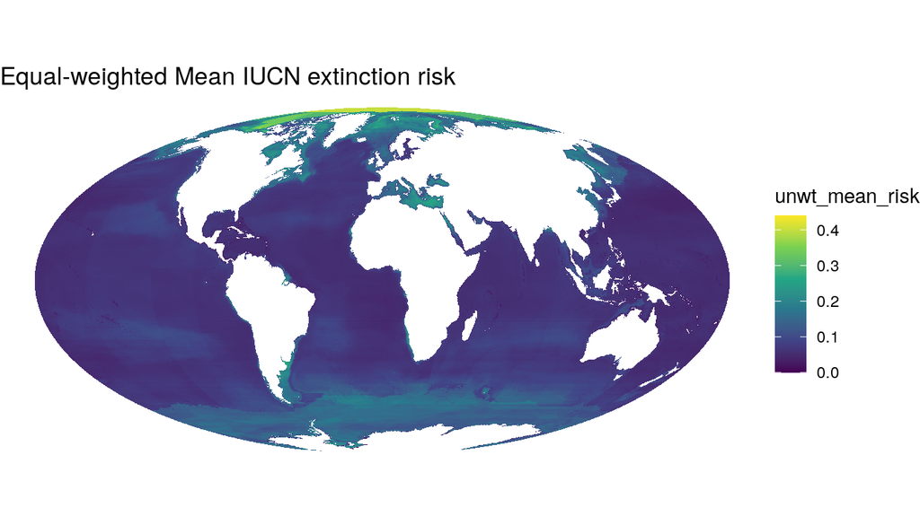

```r
ggplot(eqmean_df, aes(x, y, fill = unwt_mean_risk)) +
  geom_raster() +
  scale_fill_viridis_c() +
  theme_void() +
  coord_sf() +
  labs(title = 'Equal-weighted Mean IUCN extinction risk')
```

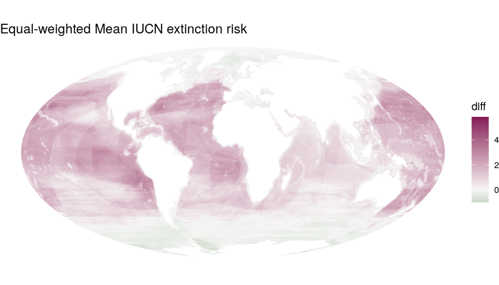

```r
div_col_vec <- hcl.colors(n = 3, palette = 'Red-Green')
ggplot(diff_df, aes(x, y, fill = diff)) +
  geom_raster() +
  scale_fill_gradient2(low = div_col_vec[3],
                       mid = div_col_vec[2],
                       high = div_col_vec[1],
                       midpoint = 0) +
  theme_void() +
  coord_sf() +
  labs(title = 'Equal-weighted Mean IUCN extinction risk')
```

## 3.5 Check that gapfilling is conservative

Since only about half the included species have non-DD IUCN extinction risk assessments, we above filled NAs using an unweighted mean of risk category across all assessed spp in the cell, then use the gapfilled values to compute FV-weighted mean and sd. Intuitively, this should provide a downward-biased FV-weighted extinction risk, in that the gapfilled values should be less than the FV-weighted mean.

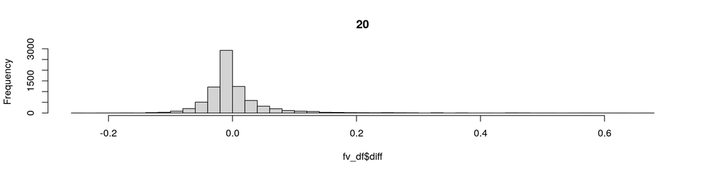

```
## [1] 0.001132425
## [1] 0.0534441
```

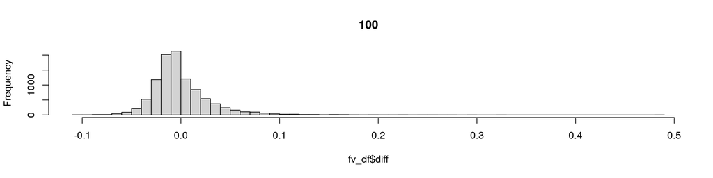

```
## [1] -0.0003545417
## [1] 0.03109906
```

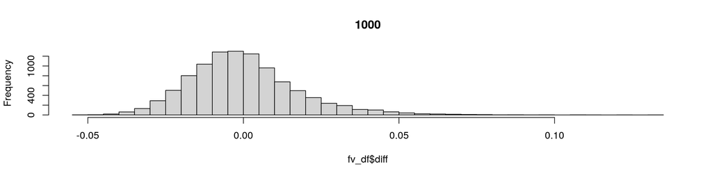

```
## [1] 9.399337e-05
## [1] 0.01768233
```

```r
rich_vec <- c(20, 100, 1000)

sims <- 10000
for(r in rich_vec) {
  raw_df <- data.frame(i = rep(1:sims, each = r)) %>%
    mutate(cat = sample(spp_info_df$cat_score, size = n(), replace = TRUE)) %>%
    group_by(i) %>%
    mutate(spp = 1:n(),
           gf = mean(cat, na.rm = TRUE),
           n_gf = sum(is.na(cat)),
           cat_gf = ifelse(is.na(cat), gf, cat),
           fe_id = sample(1:sqrt(r), size = n(), replace = TRUE)) %>%
    filter(max(cat_gf) > min(cat_gf)) %>%
    ungroup()

  fv_df <- raw_df %>%
    data.table() %>%
    .[ , .(gf = first(gf),
           n_gf = first(n_gf),
           fv = calc_fv(length(unique(spp))),
           mean_cat = mean(cat_gf),
           sd_cat = sd(cat_gf)),
       by = .(i, fe_id)] %>%
    .[ , .(gf = first(gf),
           n_gf = first(n_gf),
           fvmean_cat = Hmisc::wtd.mean(mean_cat, weights = fv),
           fvsdev_cat = Hmisc::wtd.var(mean_cat, weights = fv) %>% sqrt()),
       by = 'i'] %>%
    .[ , diff := fvmean_cat - gf]


  hist(fv_df$diff, breaks = 50, main = r)
  print(mean(fv_df$diff))
  print(sd(fv_df$diff))
}
```